# Restaurant Consumer Data R Notebook

```r
# Curso Sistemas Inteligentes.
####### Integrantes ##########
# A00354512 Anna Karen Casillas Garcia
# A00354512 Josue Emmanuel Gomez Carrillo
# A00540988 Luis Francico Gonzalez Rodriguez

#Se requiere del enlace Descargar el archivo RCData.zip y utilizar los siguientes archivos: rating_final.csv, geoplaces2.csv, chefmozcuisine.csv https://archive.ics.uci.edu/ml/datasets/Restaurant+%26+consumer+data
```

```r
#Cargamos el primer set de datos
rating <- read.delim("RCdata/rating_final.csv", sep = ",", stringsAsFactors = TRUE, header=TRUE)
str(rating)
```

```
'data.frame':   1161 obs. of  5 variables:
 $ userID        : Factor w/ 138 levels "U1001","U1002",..: 77 77 77 77 68 68 68 68 68 67 ...
 $ placeID       : int  135085 135038 132825 135060 135104 132740 132663 132732 132630 132584 ...
 $ rating        : int  2 2 2 1 1 0 1 0 1 2 ...
 $ food_rating   : int  2 2 2 2 1 0 1 0 1 2 ...
 $ service_rating: int  2 1 2 2 2 0 1 0 1 2 ...
```

```r
head(rating)
```

|  | userID | placeID | rating | food_rating | service_rating |
| --- | --- | --- | --- | --- | --- |
| 1 | U1077 | 135085 | 2 | 2 | 2 |
| 2 | U1077 | 135038 | 2 | 2 | 1 |
| 3 | U1077 | 132825 | 2 | 2 | 2 |
| 4 | U1077 | 135060 | 1 | 2 | 2 |
| 5 | U1068 | 135104 | 1 | 1 | 2 |
| 6 | U1068 | 132740 | 0 | 0 | 0 |

```r
#Para este set de datos utilizaremos solo userID, placeID y rating, creando un subset
rating <- subset(rating, select= -c(4,5))
str(rating)
```

```
'data.frame':   1161 obs. of  3 variables:
 $ userID : Factor w/ 138 levels "U1001","U1002",..: 77 77 77 77 68 68 68 68 68 67 ...
 $ placeID: int  135085 135038 132825 135060 135104 132740 132663 132732 132630 132584 ...
 $ rating : int  2 2 2 1 1 0 1 0 1 2 ...
```

```r
head(rating)
```

|  | userID | placeID | rating |
| --- | --- | --- | --- |
| 1 | U1077 | 135085 | 2 |
| 2 | U1077 | 135038 | 2 |
| 3 | U1077 | 132825 | 2 |
| 4 | U1077 | 135060 | 1 |
| 5 | U1068 | 135104 | 1 |
| 6 | U1068 | 132740 | 0 |

```r
#Cargamos Geoplaces
geoplaces <- read.delim("RCdata/geoplaces2.csv", sep = ",", stringsAsFactors = FALSE, header=TRUE)
str(geoplaces)
```

```
'data.frame':   130 obs. of  21 variables:
 $ placeID       : int  134999 132825 135106 132667 132613 135040 132732 132875 132609 135082 ...
 $ latitude      : num  18.9 22.1 22.1 23.8 23.8 ...
 $ longitude     : num  -99.2 -101 -101 -99.2 -99.2 ...
 $ the_geom_meter: chr  "0101000020957F000088568DE356715AC138C0A525FC464A41" "0101000020957F00001AD016568C4858C1243261274BA54B41" "0101000020957F0000649D6F21634858C119AE9BF528A34B41" "0101000020957F00005D67BCDDED8157C1222A2DC8D84D4941" ...
 $ name          : chr  "Kiku Cuernavaca" "puesto de tacos" "El Rinc\xf3n de San Francisco" "little pizza Emilio Portes Gil" ...
 $ address       : chr  "Revolucion" "esquina santos degollado y leon guzman" "Universidad 169" "calle emilio portes gil" ...
 $ city          : chr  "Cuernavaca" "s.l.p." "San Luis Potosi" "victoria " ...
 $ state         : chr  "Morelos" "s.l.p." "San Luis Potosi" "tamaulipas" ...
 $ country       : chr  "Mexico" "mexico" "Mexico" "?" ...
 $ fax           : chr  "?" "?" "?" "?" ...
 $ zip           : chr  "?" "78280" "78000" "?" ...
 $ alcohol       : chr  "No_Alcohol_Served" "No_Alcohol_Served" "Wine-Beer" "No_Alcohol_Served" ...
 $ smoking_area  : chr  "none" "none" "only at bar" "none" ...
 $ dress_code    : chr  "informal" "informal" "informal" "informal" ...
 $ accessibility : chr  "no_accessibility" "completely" "partially" "completely" ...
 $ price         : chr  "medium" "low" "medium" "low" ...
 $ url           : chr  "kikucuernavaca.com.mx" "?" "?" "?" ...
 $ Rambience     : chr  "familiar" "familiar" "familiar" "familiar" ...
 $ franchise     : chr  "f" "f" "f" "t" ...
 $ area          : chr  "closed" "open" "open" "closed" ...
 $ other_services: chr  "none" "none" "none" "none" ...
```

```r
head(geoplaces)
```

|  | placeID | latitude | longitude | the_geom_meter | name | address | city | state | country | fax | zip | alcohol | smoking_area | dress_code | accessibility | price | url | Rambience | franchise | area | other_services |
| --- | --- | --- | --- | --- | --- | --- | --- | --- | --- | --- | --- | --- | --- | --- | --- | --- | --- | --- | --- | --- | --- |
| 1 | 134999 | 18.91542 | -99.18487 | 0101000020957F000088568DE356715AC138C0A525FC464A41 | Kiku Cuernavaca | Revolucion | Cuernavaca | Morelos | Mexico | ? | ? | No_Alcohol_Served | none | informal | no_accessibility | medium | kikucuernavaca.com.mx | familiar | f | closed | none |
| 2 | 132825 | 22.14739 | -100.98309 | 0101000020957F00001AD016568C4858C1243261274BA54B41 | puesto de tacos | esquina santos degollado y leon guzman | s.l.p. | s.l.p. | mexico | ? | 78280 | No_Alcohol_Served | none | informal | completely | low | ? | familiar | f | open | none |
| 3 | 135106 | 22.14971 | -100.97609 | 0101000020957F0000649D6F21634858C119AE9BF528A34B41 | El Rinc\xf3n de San Francisco | Universidad 169 | San Luis Potosi | San Luis Potosi | Mexico | ? | 78000 | Wine-Beer | only at bar | informal | partially | medium | ? | familiar | f | open | none |
| 4 | 132667 | 23.75270 | -99.16336 | 0101000020957F00005D67BCDDED8157C1222A2DC8D84D4941 | little pizza Emilio Portes Gil | calle emilio portes gil | victoria | tamaulipas | ? | ? | ? | No_Alcohol_Served | none | informal | completely | low | ? | familiar | t | closed | none |
| 5 | 132613 | 23.75290 | -99.16508 | 0101000020957F00008EBA2D06DC8157C194E03B7B504E4941 | carnitas_mata | lic. Emilio portes gil | victoria | Tamaulipas | Mexico | ? | ? | No_Alcohol_Served | permitted | informal | completely | medium | ? | familiar | t | closed | none |
| 6 | 135040 | 22.13562 | -100.96971 | 0101000020957F00001B552189B84A58C15A2AAEFD2CA24B41 | Restaurant los Compadres | Camino a Simon Diaz 155 Centro | San Luis Potosi | SLP | Mexico | ? | 74000 | Wine-Beer | none | informal | no_accessibility | high | ? | familiar | f | closed | none |

```r
#Para este set de datos utilizaremos solo placeID, name, city, latitude y longitude, creando un subset
geoplaces <- subset(geoplaces, select= c(1,5,7,2,3))
str(geoplaces)
```

```
'data.frame':   130 obs. of  5 variables:
 $ placeID  : int  134999 132825 135106 132667 132613 135040 132732 132875 132609 135082 ...
 $ name     : chr  "Kiku Cuernavaca" "puesto de tacos" "El Rinc\xf3n de San Francisco" "little pizza Emilio Portes Gil" ...
 $ city     : chr  "Cuernavaca" "s.l.p." "San Luis Potosi" "victoria " ...
 $ latitude : num  18.9 22.1 22.1 23.8 23.8 ...
 $ longitude: num  -99.2 -101 -101 -99.2 -99.2 ...
```

```r
head(geoplaces)
```

|  | placeID | name | city | latitude | longitude |
| --- | --- | --- | --- | --- | --- |
| 1 | 134999 | Kiku Cuernavaca | Cuernavaca | 18.91542 | -99.18487 |
| 2 | 132825 | puesto de tacos | s.l.p. | 22.14739 | -100.98309 |
| 3 | 135106 | El Rinc\xf3n de San Francisco | San Luis Potosi | 22.14971 | -100.97609 |
| 4 | 132667 | little pizza Emilio Portes Gil | victoria | 23.75270 | -99.16336 |
| 5 | 132613 | carnitas_mata | victoria | 23.75290 | -99.16508 |
| 6 | 135040 | Restaurant los Compadres | San Luis Potosi | 22.13562 | -100.96971 |

```r
#Ahora Cargamos chefmozcuisine, unicamente contiene placeID y RCuisine, que son los datos que utilizaremos por lo que no eliminaremos ninguna columna
chfcn <- read.delim("RCdata/chefmozcuisine.csv", sep = ",", stringsAsFactors = TRUE, header=TRUE)
str(chfcn)
```

```
'data.frame':   916 obs. of  2 variables:
 $ placeID : int  135110 135109 135107 135106 135105 135104 135103 135103 135103 135103 ...
 $ Rcuisine: Factor w/ 59 levels "Afghan","African",..: 53 36 40 42 28 42 13 22 28 34 ...
```

```r
head(chfcn)
```

|  | placeID | Rcuisine |
| --- | --- | --- |
| 1 | 135110 | Spanish |
| 2 | 135109 | Italian |
| 3 | 135107 | Latin_American |
| 4 | 135106 | Mexican |
| 5 | 135105 | Fast_Food |
| 6 | 135104 | Mexican |

## 1) De los archivos anteriores generar un solo data frame que contenga todas las variables indicadas al inicio.

```r
#Combinaremos los data sets para generar solo un data set
combined_data <- merge(rating,geoplaces, by="placeID") # combinamos primero rating y geoplaces
str(combined_data)
```

```
'data.frame':   1161 obs. of  7 variables:
 $ placeID  : int  132560 132560 132560 132560 132561 132561 132561 132561 132564 132564 ...
 $ userID   : Factor w/ 138 levels "U1001","U1002",..: 50 82 87 67 26 65 130 129 60 11 ...
 $ rating   : int  0 0 1 1 1 1 0 1 2 1 ...
 $ name     : chr  "puesto de gorditas" "puesto de gorditas" "puesto de gorditas" "puesto de gorditas" ...
 $ city     : chr  "victoria" "victoria" "victoria" "victoria" ...
 $ latitude : num  23.8 23.8 23.8 23.8 23.7 ...
 $ longitude: num  -99.2 -99.2 -99.2 -99.2 -99.1 ...
```

```r
head(combined_data)
```

|  | placeID | userID | rating | name | city | latitude | longitude |
| --- | --- | --- | --- | --- | --- | --- | --- |
| 1 | 132560 | U1050 | 0 | puesto de gorditas | victoria | 23.75230 | -99.16691 |
| 2 | 132560 | U1082 | 0 | puesto de gorditas | victoria | 23.75230 | -99.16691 |
| 3 | 132560 | U1087 | 1 | puesto de gorditas | victoria | 23.75230 | -99.16691 |
| 4 | 132560 | U1067 | 1 | puesto de gorditas | victoria | 23.75230 | -99.16691 |
| 5 | 132561 | U1026 | 1 | cafe ambar | ? | 23.72682 | -99.12651 |
| 6 | 132561 | U1065 | 1 | cafe ambar | ? | 23.72682 | -99.12651 |

```r
#por ultimo del resultado obtenido lo combinamos con chefmozcuisine
combined_data <- merge(combined_data,chfcn, by="placeID")
str(combined_data)
```

```
'data.frame':   1043 obs. of  8 variables:
 $ placeID  : int  132560 132560 132560 132560 132572 132572 132572 132572 132572 132572 ...
 $ userID   : Factor w/ 138 levels "U1001","U1002",..: 82 67 50 87 112 33 55 91 83 73 ...
 $ rating   : int  0 1 0 1 0 1 2 2 2 0 ...
 $ name     : chr  "puesto de gorditas" "puesto de gorditas" "puesto de gorditas" "puesto de gorditas" ...
 $ city     : chr  "victoria" "victoria" "victoria" "victoria" ...
 $ latitude : num  23.8 23.8 23.8 23.8 22.1 ...
 $ longitude: num  -99.2 -99.2 -99.2 -99.2 -101 ...
 $ Rcuisine : Factor w/ 59 levels "Afghan","African",..: 48 48 48 48 15 15 15 15 15 15 ...
```

```r
head(combined_data)
```

|  | placeID | userID | rating | name | city | latitude | longitude | Rcuisine |
| --- | --- | --- | --- | --- | --- | --- | --- | --- |
| 1 | 132560 | U1082 | 0 | puesto de gorditas | victoria | 23.75230 | -99.16691 | Regional |
| 2 | 132560 | U1067 | 1 | puesto de gorditas | victoria | 23.75230 | -99.16691 | Regional |
| 3 | 132560 | U1050 | 0 | puesto de gorditas | victoria | 23.75230 | -99.16691 | Regional |
| 4 | 132560 | U1087 | 1 | puesto de gorditas | victoria | 23.75230 | -99.16691 | Regional |
| 5 | 132572 | U1112 | 0 | Cafe Chaires | San Luis Potosi | 22.14165 | -100.99271 | Cafeteria |
| 6 | 132572 | U1033 | 1 | Cafe Chaires | San Luis Potosi | 22.14165 | -100.99271 | Cafeteria |

```r
combined_data[1:6,]
```

|  | placeID | userID | rating | name | city | latitude | longitude | Rcuisine |
| --- | --- | --- | --- | --- | --- | --- | --- | --- |
| 1 | 132560 | U1082 | 0 | puesto de gorditas | victoria | 23.75230 | -99.16691 | Regional |
| 2 | 132560 | U1067 | 1 | puesto de gorditas | victoria | 23.75230 | -99.16691 | Regional |
| 3 | 132560 | U1050 | 0 | puesto de gorditas | victoria | 23.75230 | -99.16691 | Regional |
| 4 | 132560 | U1087 | 1 | puesto de gorditas | victoria | 23.75230 | -99.16691 | Regional |
| 5 | 132572 | U1112 | 0 | Cafe Chaires | San Luis Potosi | 22.14165 | -100.99271 | Cafeteria |
| 6 | 132572 | U1033 | 1 | Cafe Chaires | San Luis Potosi | 22.14165 | -100.99271 | Cafeteria |

## 2) Realizar una análisis descriptivo de las variables e indica si existen datos perdidos en algunas de ellas. De ser así, realiza un análisis para determinar y justificar la decisión que tomes sobre dichos datos perdidos. Para el caso de los datos perdidos de la variable city, puedes investigar al menos los paquetes “revgeo” o “ggmap” de R, para recuperar el nombre de la ciudad con la latitud y longitud.

```r
comds <- combined_data
str(comds)
```

```
'data.frame':   1043 obs. of  8 variables:
 $ placeID  : int  132560 132560 132560 132560 132572 132572 132572 132572 132572 132572 ...
 $ userID   : Factor w/ 138 levels "U1001","U1002",..: 82 67 50 87 112 33 55 91 83 73 ...
 $ rating   : int  0 1 0 1 0 1 2 2 2 0 ...
 $ name     : chr  "puesto de gorditas" "puesto de gorditas" "puesto de gorditas" "puesto de gorditas" ...
 $ city     : chr  "victoria" "victoria" "victoria" "victoria" ...
 $ latitude : num  23.8 23.8 23.8 23.8 22.1 ...
 $ longitude: num  -99.2 -99.2 -99.2 -99.2 -101 ...
 $ Rcuisine : Factor w/ 59 levels "Afghan","African",..: 48 48 48 48 15 15 15 15 15 15 ...
```

- placeID y userID son variables de identificación, por lo tanto únicas así que ambas son categoricas
- Nombre y Ciudad son así mismo variables categoricas, únicas
- Rating es una variable númerica
- latitude y longitude, aunque n´´úmericas son parte de una dirección ** En nuestra opinión las más útiles son rating y tipo de cocina (Rcuisine), siendo raiting númerica y Rcuisine categorica **

### Distribución place ID

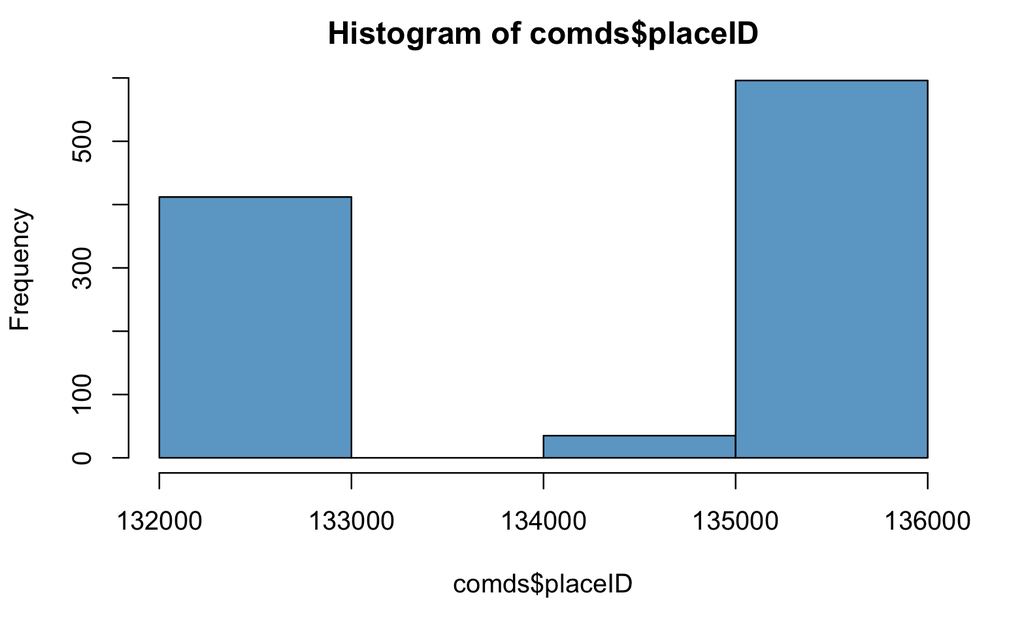

```r
hist(comds$placeID, col = 'skyblue3', breaks = 3)
```

```r
sum(is.na(comds))
```

```
[1] 0
```

### No se muestran “NA” en el set de datos

#### Veamos la distribución de opiniones

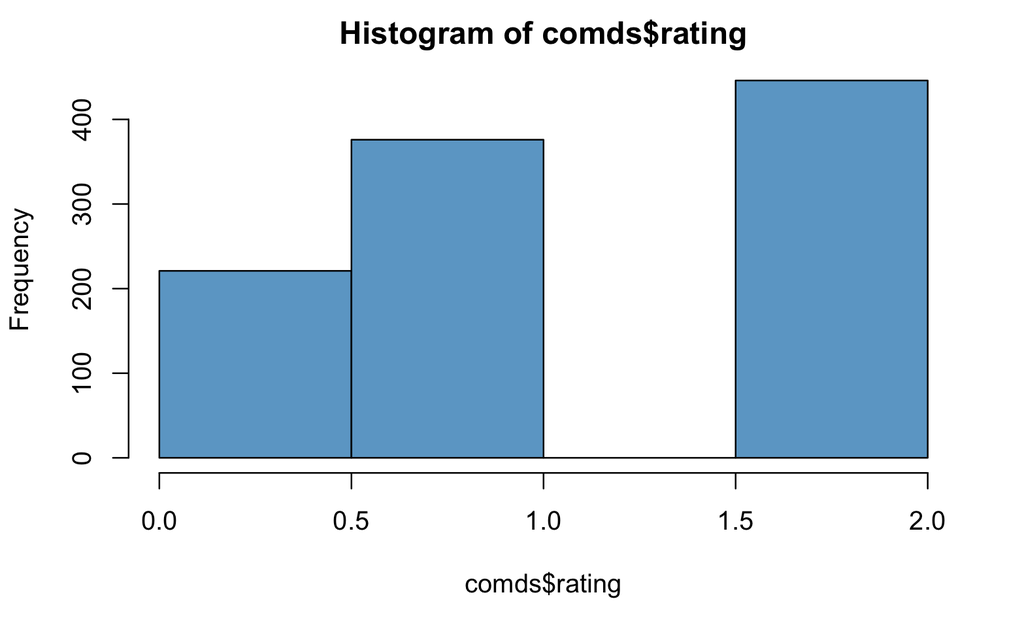

```r
hist(comds$rating, col = 'skyblue3', breaks = 3)
```

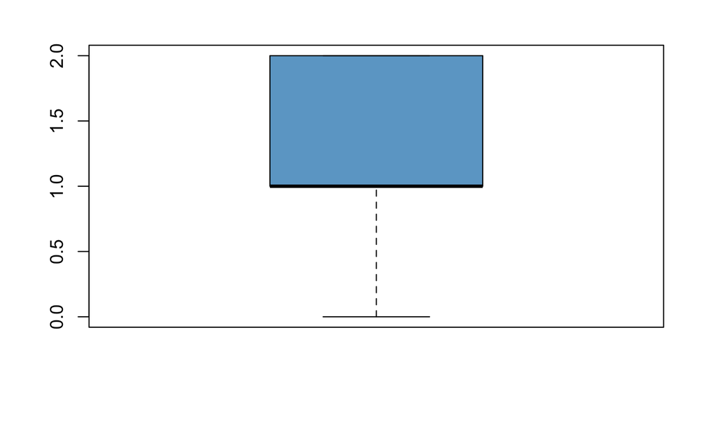

```r
boxplot(comds$rating, col = 'skyblue3')
```

### Usuarios (opiniones)

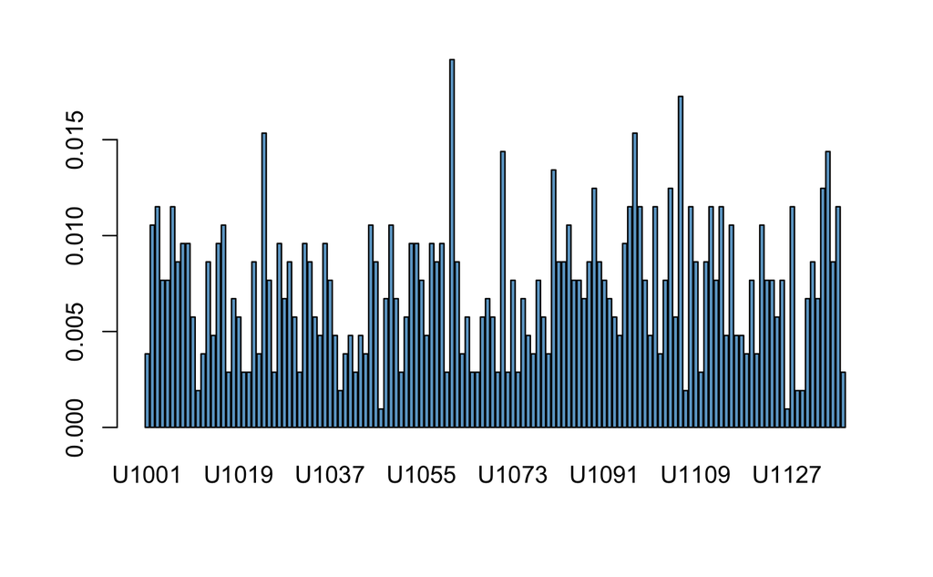

```r
barplot(prop.table(table(comds$userID)), col = 'skyblue3')
```

### Distribución por tipo de comida

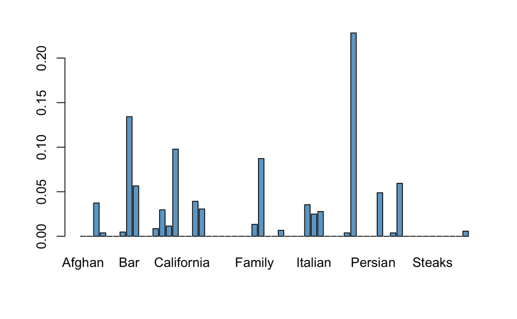

```r
barplot(prop.table(table(comds$Rcuisine)), col = 'skyblue3')
```

### Número total de regitros sin ciudad

```r
sum(comds$city=="?")
```

```
[1] 89
```

### Mediante el uso de REVGEO buscamos el nombre de las ciudades para los registros que no tienen o están marcados con “?”

```r
#install.packages("revgeo")
#install.packages("dplyr")
library(revgeo)
library(dplyr)
latlong <-subset(comds,comds$city == "?",select=placeID:longitude,stringsAsFactors=FALSE)
latlong
```

|  | placeID | userID | rating | name | city | latitude | longitude |
| --- | --- | --- | --- | --- | --- | --- | --- |
| 24 | 132584 | U1050 | 0 | Gorditas Dona Tota | ? | 23.75236 | -99.16529 |
| 25 | 132584 | U1063 | 2 | Gorditas Dona Tota | ? | 23.75236 | -99.16529 |
| 26 | 132584 | U1103 | 1 | Gorditas Dona Tota | ? | 23.75236 | -99.16529 |
| 27 | 132584 | U1123 | 1 | Gorditas Dona Tota | ? | 23.75236 | -99.16529 |
| 28 | 132584 | U1067 | 2 | Gorditas Dona Tota | ? | 23.75236 | -99.16529 |
| 29 | 132584 | U1107 | 2 | Gorditas Dona Tota | ? | 23.75236 | -99.16529 |
| 30 | 132594 | U1082 | 0 | tacos de barbacoa enfrente del Tec | ? | 23.75217 | -99.16571 |
| 31 | 132594 | U1050 | 0 | tacos de barbacoa enfrente del Tec | ? | 23.75217 | -99.16571 |
| 32 | 132594 | U1087 | 1 | tacos de barbacoa enfrente del Tec | ? | 23.75217 | -99.16571 |
| 33 | 132594 | U1068 | 1 | tacos de barbacoa enfrente del Tec | ? | 23.75217 | -99.16571 |

[output cut: 79 more lines]

```r
cities <- revgeo(latlong$longitude, latlong$latitude,  output = 'hash', item='city')
```

[output not shown]

[output cut: 74 more lines]

```r
cities
```

```
$city
 [1] "Ciudad Victoria" "Ciudad Victoria" "Ciudad Victoria" "Ciudad Victoria"
 [5] "Ciudad Victoria" "Ciudad Victoria" "Ciudad Victoria" "Ciudad Victoria"
 [9] "Ciudad Victoria" "Ciudad Victoria" "Ciudad Victoria" "Ciudad Victoria"
[13] "Ciudad Victoria" "Ciudad Victoria" "Ciudad Victoria" "Ciudad Victoria"
[17] "Ciudad Victoria" "Ciudad Victoria" "San Luis Potosí" "San Luis Potosí"
[21] "San Luis Potosí" "San Luis Potosí" "San Luis Potosí" "San Luis Potosí"
[25] "San Luis Potosí" "San Luis Potosí" "San Luis Potosí" "San Luis Potosí"
[29] "San Luis Potosí" "San Luis Potosí" "San Luis Potosí" "San Luis Potosí"
[33] "San Luis Potosí" "San Luis Potosí" "San Luis Potosí" "San Luis Potosí"
[37] "San Luis Potosí" "San Luis Potosí" "San Luis Potosí" "San Luis Potosí"
[41] "San Luis Potosí" "San Luis Potosí" "San Luis Potosí" "San Luis Potosí"
[45] "San Luis Potosí" "San Luis Potosí" "San Luis Potosí" "San Luis Potosí"
[49] "San Luis Potosí" "San Luis Potosí" "San Luis Potosí" "San Luis Potosí"
[53] "San Luis Potosí" "San Luis Potosí" "San Luis Potosí" "San Luis Potosí"
[57] "San Luis Potosí" "San Luis Potosí" "San Luis Potosí" "San Luis Potosí"
[61] "San Luis Potosí" "San Luis Potosí" "San Luis Potosí" "San Luis Potosí"
[65] "San Luis Potosí" "San Luis Potosí" "Cuernavaca"      "Cuernavaca"
[69] "Cuernavaca"      "Cuernavaca"      "Cuernavaca"      "Cuernavaca"
[73] "Cuernavaca"      "Cuernavaca"      "Cuernavaca"      "Cuernavaca"
[77] "Cuernavaca"      "Cuernavaca"      "Ciudad Victoria" "Ciudad Victoria"
[81] "Ciudad Victoria" "Ciudad Victoria" "Ciudad Victoria" "Ciudad Victoria"
[85] "Ciudad Victoria" "Cuernavaca"      "Cuernavaca"      "Cuernavaca"
[89] "Cuernavaca"
```

```r
latlong$city <- cities$city
latlong
```

|  | placeID | userID | rating | name | city | latitude | longitude |
| --- | --- | --- | --- | --- | --- | --- | --- |
| 24 | 132584 | U1050 | 0 | Gorditas Dona Tota | Ciudad Victoria | 23.75236 | -99.16529 |
| 25 | 132584 | U1063 | 2 | Gorditas Dona Tota | Ciudad Victoria | 23.75236 | -99.16529 |
| 26 | 132584 | U1103 | 1 | Gorditas Dona Tota | Ciudad Victoria | 23.75236 | -99.16529 |
| 27 | 132584 | U1123 | 1 | Gorditas Dona Tota | Ciudad Victoria | 23.75236 | -99.16529 |
| 28 | 132584 | U1067 | 2 | Gorditas Dona Tota | Ciudad Victoria | 23.75236 | -99.16529 |
| 29 | 132584 | U1107 | 2 | Gorditas Dona Tota | Ciudad Victoria | 23.75236 | -99.16529 |
| 30 | 132594 | U1082 | 0 | tacos de barbacoa enfrente del Tec | Ciudad Victoria | 23.75217 | -99.16571 |
| 31 | 132594 | U1050 | 0 | tacos de barbacoa enfrente del Tec | Ciudad Victoria | 23.75217 | -99.16571 |
| 32 | 132594 | U1087 | 1 | tacos de barbacoa enfrente del Tec | Ciudad Victoria | 23.75217 | -99.16571 |
| 33 | 132594 | U1068 | 1 | tacos de barbacoa enfrente del Tec | Ciudad Victoria | 23.75217 | -99.16571 |

[output cut: 79 more lines]

```r
for(i in 1:nrow(latlong)) {
    row <- latlong[i,]
    comds$city[which(comds$placeID == row$placeID)] <- as.character(row$city)
}
comds
```

| placeID | userID | rating | name | city | latitude | longitude | Rcuisine |
| --- | --- | --- | --- | --- | --- | --- | --- |
| 132560 | U1082 | 0 | puesto de gorditas | victoria | 23.75230 | -99.16691 | Regional |
| 132560 | U1067 | 1 | puesto de gorditas | victoria | 23.75230 | -99.16691 | Regional |
| 132560 | U1050 | 0 | puesto de gorditas | victoria | 23.75230 | -99.16691 | Regional |
| 132560 | U1087 | 1 | puesto de gorditas | victoria | 23.75230 | -99.16691 | Regional |
| 132572 | U1112 | 0 | Cafe Chaires | San Luis Potosi | 22.14165 | -100.99271 | Cafeteria |
| 132572 | U1033 | 1 | Cafe Chaires | San Luis Potosi | 22.14165 | -100.99271 | Cafeteria |
| 132572 | U1055 | 2 | Cafe Chaires | San Luis Potosi | 22.14165 | -100.99271 | Cafeteria |
| 132572 | U1091 | 2 | Cafe Chaires | San Luis Potosi | 22.14165 | -100.99271 | Cafeteria |
| 132572 | U1083 | 2 | Cafe Chaires | San Luis Potosi | 22.14165 | -100.99271 | Cafeteria |
| 132572 | U1073 | 0 | Cafe Chaires | San Luis Potosi | 22.14165 | -100.99271 | Cafeteria |

[output cut: 990 more lines]

### Corroboramos que ya no hay regitros sin ciudad o con valor = ‘?’

```r
sum(comds$city=="?")
```

```
[1] 0
```

### Corroboramos que no hay registros sin valor (NA)

```r
#sum(is.na(latlong))
sum(is.na(comds))
```

```
[1] 0
```

```r
#Volver Categórica la columna city
comds$city = as.factor(comds$city)
```

## 3) ¿De qué ciudades son los restaurantes del estudio?

#### Ciudades de los restaurantes del estudio:

```r
levels( comds$city )
```

```
 [1] "Cd Victoria"      "Cd. Victoria"     "Ciudad Victoria"  "cuernavaca"
 [5] "Cuernavaca"       "Jiutepec"         "s.l.p"            "s.l.p."
 [9] "san luis potos"   "san luis potosi"  "San Luis Potosi"  "San Luis Potosí"
[13] "san luis potosi " "Soledad"          "victoria"         "victoria "
```

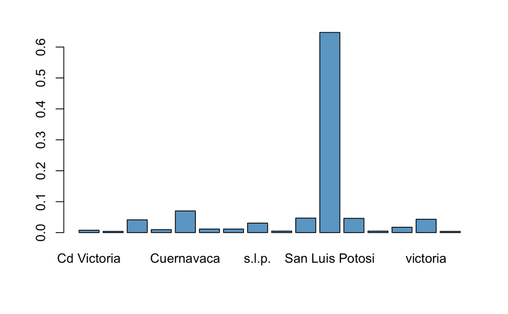

```r
barplot(prop.table(table(comds$city)), col = 'skyblue3')
```

#### Vamos a agrupar las ciudades por un nombre en común.

```r
lev <- with(comds, levels(city))
lev[lev=="Cd Victoria"] <- "Ciudad Victoria"
lev[lev=="Cd Victoria "] <- "Ciudad Victoria"
lev[lev=="Cd. Victoria"] <- "Ciudad Victoria"
lev[lev=="victoria "] <- "Ciudad Victoria"
lev[lev=="victoria"] <- "Ciudad Victoria"
lev[lev=="cuernavaca "] <- "Cuernavaca"
lev[lev=="cuernavaca"] <- "Cuernavaca"
lev[lev=="san luis potos"] <- "San Luis Potosí"
lev[lev=="slp"] <- "San Luis Potosí"
lev[lev=="s.l.p"] <- "San Luis Potosí"
lev[lev=="san luis potosi"] <- "San Luis Potosí"
lev[lev=="san luis potosi "] <- "San Luis Potosí"
lev[lev=="s.l.p."] <- "San Luis Potosí"
lev[lev=="San Luis Potosi"] <- "San Luis Potosí"

comds <- within(comds, levels(city) <- lev)
levels(comds$city)
```

```
[1] "Ciudad Victoria" "Cuernavaca"      "Jiutepec"        "San Luis Potosí"
[5] "Soledad"
```

### Volvemos a imprimir las ciudades, para corroborar el nuevo agrupamiento.

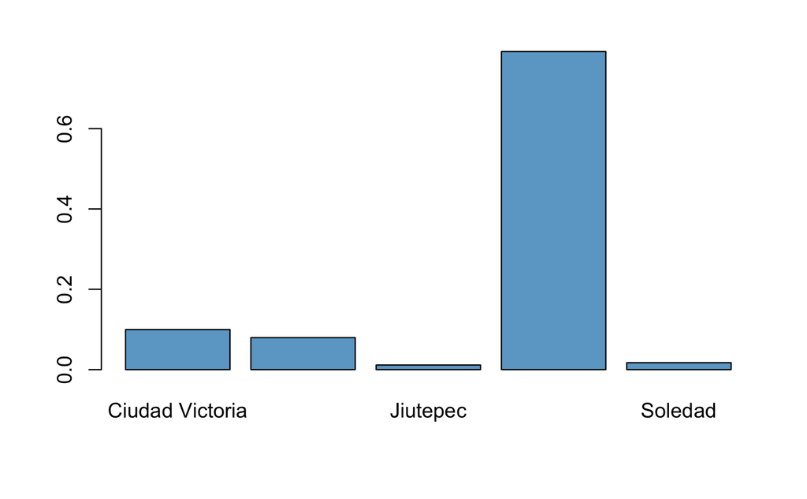

```r
barplot(prop.table(table(comds$city)), col = 'skyblue3')
```

### Número total de regitros sin ciudad, o el campo en ‘?’

```r
sum(comds$city=="?")
```

```
[1] 0
```

## 4) Si consideramos la popularidad de un lugar como aquellos que tienen la mayor cantidad de evaluaciones por parte de los usiarios (independientemente de si fue positiva o negativa la evaluación), obtener los nombres de los 10 restaurantes más evaluados/populares. ¿Cuántos restaurantes difernetes hay en total?

```r
restByRating <- aggregate(comds$rating, by=list(Rest=comds$name), FUN=sum)[order(comds$rating),]
names(restByRating)[2] <- "SumRating"
restByRating <- restByRating[order(restByRating$SumRating,decreasing = TRUE),]
restByRating
```

|  | Rest | SumRating |
| --- | --- | --- |
| 6 | Cafeteria y Restaurant El Pacifico | 66 |
| 33 | La Cantina Restaurante | 64 |
| 90 | Tortas Locas Hipocampo | 48 |
| 58 | puesto de tacos | 41 |
| 44 | Luna Cafe | 40 |
| 56 | Preambulo Wifi Zone Cafe | 38 |
| 32 | la Cantina | 30 |
| 36 | La Fontana Pizza Restaurante and Cafe | 27 |
| 24 | Gorditas Doa Gloria | 25 |
| 39 | La Posada del Virrey | 25 |

[output cut: 990 more lines]

```r
#head(restByRating)
```

```r
dim(restByRating )
```

```
[1] 1043    2
```

## 5) ¿De qué tipo de comida/cocina son los 10 restaurantes más populares encontrados en el inciso anterior? ¿Cuántos tipos de cocina diferentes hay en total?

### Usaremos el ID de cada restaurant (placeID) para encontrar su tipo de comida

```r
restByRating <- aggregate(comds$rating, by=list(Id=comds$placeID,Rest=comds$name), FUN=sum)[order(comds$rating),]
names(restByRating)[3] <- "SumRating"
restByRating <- restByRating[order(restByRating$SumRating,decreasing = TRUE),]
head(restByRating, n=10)
```

|  | Id | Rest | SumRating |
| --- | --- | --- | --- |
| 6 | 135032 | Cafeteria y Restaurant El Pacifico | 66 |
| 34 | 135052 | La Cantina Restaurante | 64 |
| 91 | 135085 | Tortas Locas Hipocampo | 48 |
| 59 | 132825 | puesto de tacos | 41 |
| 45 | 135041 | Luna Cafe | 40 |
| 57 | 135030 | Preambulo Wifi Zone Cafe | 38 |
| 33 | 135026 | la Cantina | 30 |
| 37 | 135053 | La Fontana Pizza Restaurante and Cafe | 27 |
| 24 | 132834 | Gorditas Doa Gloria | 25 |
| 21 | 135025 | El Rincon de San Francisco | 25 |

### Tipos distintos de cocina: 8

```r
out <- subset(comds, placeID %in% c(135032, 135052,135085,132825,135041,135030,135026,135053,132834,135025))
agg <- aggregate(out$placeID, by=list(TiposCocina=out$Rcuisine), FUN=mean)[order(out$placeID),]
agg <- agg[ -c(2)]

agg <- na.omit(agg)

totalTipos <- unique(agg$TiposCocina)
length(totalTipos)
```

```
[1] 8
```

```r
head(agg, 8)
```

|  | TiposCocina |
| --- | --- |
| 1 | Bar |
| 2 | Bar_Pub_Brewery |
| 3 | Cafe-Coffee_Shop |
| 4 | Cafeteria |
| 5 | Contemporary |
| 6 | Fast_Food |
| 7 | Mexican |
| 8 | Pizzeria |

```r
NA
```

## 6) Generar la matriz de Utilidad considerando los renglones con la variable userID, las columnas con placeID, y los valores de la matriz con rating. A partir de dicha matriz de utilidad aplicar la factorización SVD (Singular Value Decomposition) para obtener la matriz de variables latentes para los restaurantes.

```r
library(Matrix)
#Matriz de utilidad/Tabla de Contingencias:
UtMx <- with(comds,
             tapply(rating, list(userID,placeID),
            sum, default=NA) )

dim(UtMx)  # dimension de UtMx 138 usuarios y 95 placesID
```

```
[1] 138  95
```

```r
#UtMx
UtMx[is.na(UtMx)] <- 0 # como tiene muchas entradas NA las convetimos a 0s para matematicamente poder ser manipuladas
nombres <-colnames(UtMx) # guardamos el vector de nombres para facil acceso
UtMx[1:6,1:6]
```

```
      132560 132572 132583 132584 132594 132608
U1001      0      0      0      0      0      0
U1002      0      0      0      0      0      0
U1003      0      0      0      0      0      0
U1004      0      0      0      0      0      0
U1005      0      0      0      0      0      0
U1006      0      1      0      0      0      0
```

```r
#aplicamos el SVD a la traspuesta a la matriz de utlidad:
library(irlba)
Msvd <- svd( t(UtMx) )  # estamos tomando la traspuesta para que los placesIDs queden en los renglones y calculamos la SVD
str(Msvd)  # para ver la estructura de las tres matrices: U*D*V
```

```
List of 3
 $ d: num [1:95] 22.7 15.5 13.4 12.2 12 ...
 $ u: num [1:95, 1:95] -1.14e-16 4.22e-02 4.30e-17 -4.01e-17 2.86e-17 ...
 $ v: num [1:138, 1:95] 0.039 0.149 0.067 0.119 0.122 ...
```

```r
           # se Observa que la matriz diagonal "d" esta dada solo como un vector unidimensional.
```

## 7) Si a un usuario le gustó el restaurante “Gorditas Doña Gloria” con placeID: 132834, ¿Qué otros 12 restaurantes (indicar los nombres) le podrías recomendar usando la descomposición SVD con el método de correlación de “pearson” y considerando los 10 valores singulares más grandes de la SVD? Nota: no importa por el momento de qué ciudad sea el restaurante.

```r
#Recomendacion con Matriz de correlacion y SVD-TRUNCADO:
utrunc <- Msvd$u[,1:10]

corr_mx <- cor( t(utrunc), use="pairwise.complete.obs", method = "pearson")
#corr_mx

dim(corr_mx)
```

```
[1] 95 95
```

```r
# Seleccionamos a "Gorditas Doña Gloria":
placeId <- "132834"
#str(nombres)
placeIndex <- match(c(placeId),nombres) # obtenemos el index de este placeID en nombres que guardamos previamente
str(placeIndex) #index obtenido
```

```
 int 29
```

```r
mis_recomendaciones <- corr_mx[,placeIndex] # obtenemos las recomentaciones con base a el place ID
#mis_recomendaciones

# Seleccionemos aquellas correlaciones altas:
tops <- which(mis_recomendaciones[]>0.42 & mis_recomendaciones[] < 1.0, arr.ind = TRUE)
#nombres[tops]
#mis_recomendaciones[tops]
top_recomendaciones <- cbind(mis_recomendaciones[tops], nombres[tops])
top_recomendaciones
```

```
      [,1]                [,2]
 [1,] "0.74377306401641"  "132754"
 [2,] "0.681657558826731" "132825"
 [3,] "0.783641707676865" "132862"
 [4,] "0.520579906932491" "132872"
 [5,] "0.5380195142333"   "132951"
 [6,] "0.431769632828676" "135025"
 [7,] "0.444380914581951" "135028"
 [8,] "0.611594584319211" "135030"
 [9,] "0.578208374754708" "135042"
[10,] "0.572745199176615" "135044"
[11,] "0.725104509842075" "135079"
[12,] "0.924958889823934" "135085"
```

### Recomendación de lugares para los usuarios que les gustó el restaurante “Gorditas Doña Gloria”

```r
result <- subset(comds, placeID %in% top_recomendaciones[,2])
recomend <- unique(result$name)
paste(c("Te recomendamos los 12 siguientes lugares cerca de tí:", recomend))
```

```
 [1] "Te recomendamos los 12 siguientes lugares cerca de tí:"
 [2] "Cabana Huasteca"
 [3] "puesto de tacos"
 [4] "La Posada del Virrey"
 [5] "Pizzeria Julios"
 [6] "VIPS"
 [7] "El Rincon de San Francisco"
 [8] "La Virreina"
 [9] "Preambulo Wifi Zone Cafe"
[10] "Restaurant Oriental Express"
[11] "Restaurant Wu Zhuo Yi"
[12] "Koye Sushi"
[13] "Tortas Locas Hipocampo"
```